## A Simulation Exercise - the Exponential Distribution

##### Author: Arnie Larson

##### Date: 12/8/2016

#### Overview

The goal of this exercise is to simulate taking samples from a known distribution in order to investigate the behavaivor of the sample means. According to theory, if a sample of observations are independent and indentically sampled, then the mean of the sample will itself be distributed with a mean and variance related to the mean and variance of the underlying population. This simulation investigates this behaivor and makes a comparison with the theoretical expectation.

#### Theory

The simulation draws from the [exponential distribution](https://en.wikipedia.org/wiki/Exponential_distribution). This distribution is both similar in form and has an interesting relationship to the Poisson distribution. The exponential distribution arises by considering a continous random variable $x$ representing the time between two adjacent events from a Poisson process or distribution.

$P(x, \lambda) = \lambda exp(-\lambda); \mu = E[x] = \int_0^{\infty} x P(x, \lambda) dx = \lambda^{-1}$ $\sigma^2 = Var[x] = E[(x-\mu)^2] = \int_0^{\infty} (x^2 - \mu^2) P(x, \lambda) dx = \lambda^{-2}$

According to the central limit theorem, provided that the sample mean and variance are finite, if we take a sample of $N$ observations from a known distribution, we expect the sample mean to be distributed normally with a mean, variance and standard deviation related to the underlying population distribution. In our case, the underlying population is the exponential distribution, with known $\mu$ and $\sigma$, and the sample average $\bar x$ should be normally distributed with

$E[\bar x] = \mu = \lambda^{-1}$ $Var[\bar x] = \sigma^2 / N = 1 / (\lambda^{2} N)$ $SD[\bar x] = \sigma / \sqrt{N} = 1 / (\lambda \sqrt{N})$

#### The Simulation

This simulation creates a set of samples of $N=40$ observations in order to investigate the distribution of the mean of the samples. To perform the simulation with sets of $N$ observations the r function `rexp(n, lambda)` is used to make independent observations. The observations are partitioned into sets of $N=40$ observations. Each set of $N=40$ observations is considered an independent sample. For the simulation $\lambda = 0.2$ was chosen. For each sample the sample average $\bar x$ is calculated and it’s distribution is investigated and compared to the theoretical expectation. With $N$ and $\lambda$ chosen, we can expect, in the limit of many simulated samplings, the average of the sample averages will approach $\mu = \lambda^{-1}=5$, the variance of the sample averages will approach $\sigma/ \sqrt{N} = 1 / (\lambda^{2} N) = 25/40 = 0.625$, and the standard deviation of the sample averages will appoach $1 / (\lambda \sqrt{N}) =5/\sqrt{40} =0.79057$. For the 1000 simulations we can compare the simulatied distribution of $\bar x$ to the theoretical normal distribution.

```r
set.seed(123)
nsims <- 1000  # number of samples
lambda <- 0.2
n <- 40       # number of observations in each sample
# Collect the simulations in a data matrix, each row is a sample of n observations
simulation <- matrix(rexp(n*nsims,lambda),nsims)
# Calculate the mean for each sample:
means <- apply(simulation, 1, mean)

# The sample means (aveage of all the means)
mean(means)  # Expect that 1/0.2 = 5
```

```
## [1] 5.011911
```

```r
# The variance of the sample means
var(means)    # Expect that sigma^2/N = 25/40 = 0.625
```

```
## [1] 0.6088292
```

```r
# The standard deviation of the sample means
sd(means)    # Expect that sigma/sqrt(N) = 5/sqrt(40) = 0.7905
```

```
## [1] 0.7802751
```

The simulated sample averages and distribution can be visualized with a simple histogram. We expect that on average about $2/3$ of the simulations will have $\bar x$ falling between $5 \pm 0.7905$.

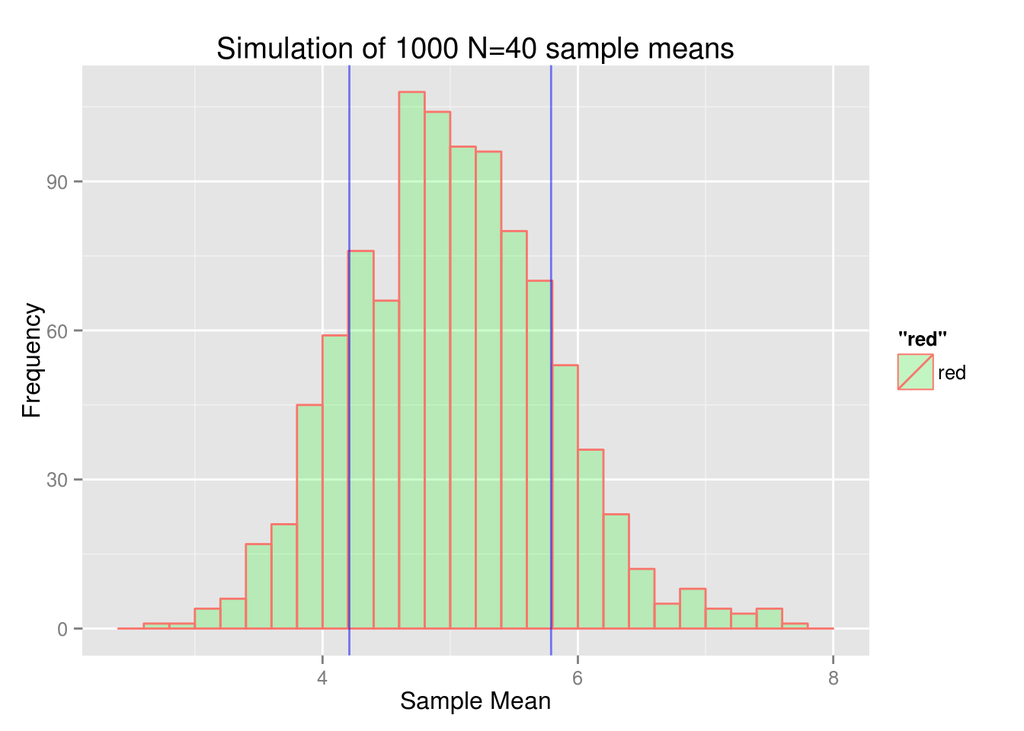

```r
library(ggplot2)
q<-qplot(means, col="red",fill=I("green"),alpha=I(.2),fig.align='center',
      binwidth=0.2, main="Simulation of 1000 N=40 sample means",
      xlab="Sample Mean", ylab="Frequency")
q + geom_vline(xintercept=5+.79, col="blue", alpha=I(.5)) +
    geom_vline(xintercept=5-.79, col="blue", alpha=I(.5))
```

This shows that the simulations of the draws of $N=40$ observations indeed appears like it could be distributed normally with the expected theoretical $\mu = 5$ and $\sigma/ \sqrt{N} = 0.7905$. We can also plot a density estimate of this simulation against the theoretical normal distribution. This shows that the density of the 1000 simulations is becoming close to representative of the theoretical distribution.

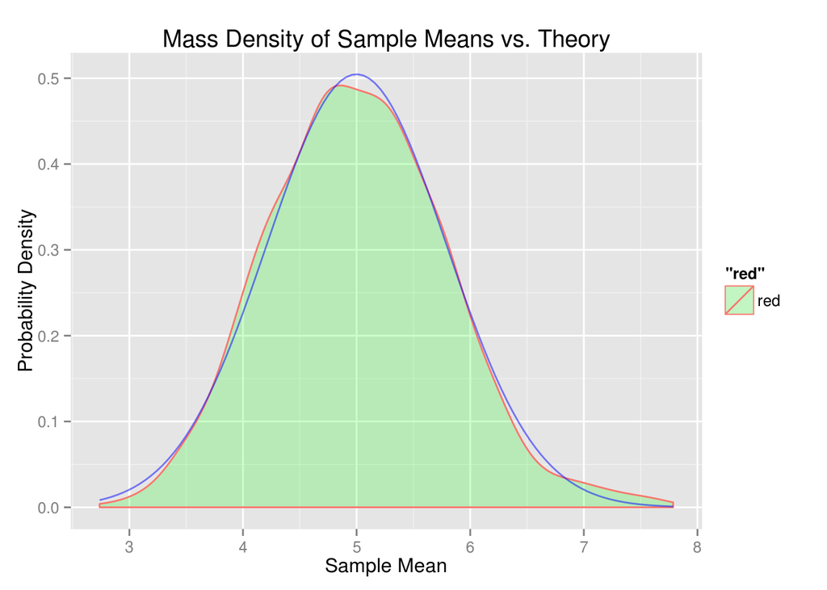

```r
q<-qplot(means,col="red",fill=I("green"),alpha=I(.2),geom="density",
      main="Mass Density of Sample Means vs. Theory",
      xlab="Sample Mean", ylab="Probability Density")
q+stat_function(fun=dnorm, args = list(mean = 5, sd = 0.7905), col="blue",alpha=I(.5))
```

#### Conclusion

That is pretty neat eh? This simple exercise attempts to show the central limit theorem. We found that our simuluation of samples from an [exponential distribution](https://en.wikipedia.org/wiki/Exponential_distribution) does appear to show the expected behaivor: that the sample averages are distributed normally with mean and variance related to the Sample size $N$ and the population mean $\mu$ and variance $\sigma^2$.